# Mass to length to probablity

# Overview

This document recreates the sampling probabilities from Morin et al. 2004 based on lengths.

## Setup

```r
library(tidyverse)
library(sizeSpectra)
```

## Morin’s probabilities

Figure 1 in Morin et al. 2004 shows sampling probabilities for different mesh sizes.

Where $p$ is the sampling probability, $RL$ is the ratio of body length to mesh size ( $L/M$ ) and $M$ is mesh size, in mm.

Table 1 shows parameter estimates for $a, b, c$

The equation returns the logit of the probability, and we can back transform it with the `plogis()` function.

```r
morin_ln_p  <- function(
    a = -2.84,
    b = 5.8,
    c = -3.18,
    L,
    M = 0.25){
  RL = L / M
  a + b * log10(RL) + c * log10(RL)*log10(M)
}
```

The function now takes arguments for length `L` and the mesh size, `M`.

```r
plogis(morin_ln_p(L = 1, M = c(0.125, 0.25, 0.5)))
```

```
[1] 0.9932500 0.8587107 0.3087740
```

These probabilities approx. match fig 1. in Morin.

## Recreate Figure 1.

Now I will recreate the sampling probabilities from figure 1 in Morin for body lengths from 0.1 to 13 mm and for mesh sizes 0.125, 0.25, 0.5 and 1.

```r
p_length <- tibble(
  xl = seq(.1, 13, length.out = 1000)) |>
  mutate(p_125 = plogis(morin_ln_p(L = xl,
                                   M = .125)),
         p_250 = plogis(morin_ln_p(L = xl,
                                   M = .250)),
         p_500 = plogis(morin_ln_p(L = xl,
                                   M = .50)),
         p_1000 = plogis(morin_ln_p(L = xl,
                                    M = 1))) |>
  pivot_longer(p_125:p_1000,
               names_to = "mesh",
               values_to = "probablity")
p_length
```

```
# A tibble: 4,000 × 3
      xl mesh   probablity
   <dbl> <chr>       <dbl>
 1 0.1   p_125    0.0246
 2 0.1   p_250    0.00271
 3 0.1   p_500    0.000519
 4 0.1   p_1000   0.000177
 5 0.113 p_125    0.0383
 6 0.113 p_250    0.00406
 7 0.113 p_500    0.000741
 8 0.113 p_1000   0.000240
 9 0.126 p_125    0.0565
10 0.126 p_250    0.00582
# ℹ 3,990 more rows
```

And the plot:

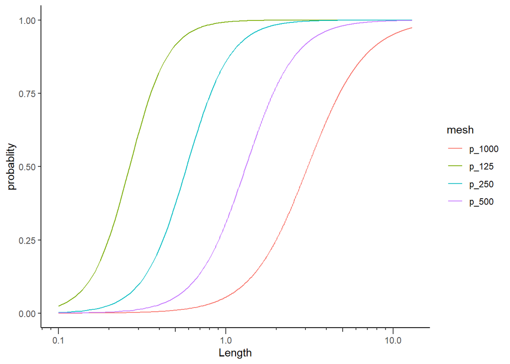

```r
p_length |>
  ggplot(aes(x = xl,
             y = probablity,
             color = mesh,
             group = mesh)) +
  geom_line() +
  scale_x_log10(guide = "axis_logticks") +
  theme_classic() +
  labs(x = "Length")
```

# Convert length to mass

Now, we will convert the length to mass with

$$M = aL^b$$

We will use generic invertebrate parameters for a and b from Benke et al. 1999: $a = 0.005, b = 2.778$

Conveniently, `sizeSpectra` has a `lengthToMass()` and a `massToLength()` function which we can use. (I just found these, don’t think I knew about them before. On a encouraging note, it’s the same equation that Jim derived as well.)

We will do this by adding an `xm` column to the `p_length` tibble

```r
p_length_mass <- p_length |>
  mutate(xm = lengthToMass(xl,
                           LWa = 0.005,
                           LWb = 2.78))
p_length_mass
```

```
# A tibble: 4,000 × 4
      xl mesh   probablity         xm
   <dbl> <chr>       <dbl>      <dbl>
 1 0.1   p_125    0.0246   0.00000830
 2 0.1   p_250    0.00271  0.00000830
 3 0.1   p_500    0.000519 0.00000830
 4 0.1   p_1000   0.000177 0.00000830
 5 0.113 p_125    0.0383   0.0000116
 6 0.113 p_250    0.00406  0.0000116
 7 0.113 p_500    0.000741 0.0000116
 8 0.113 p_1000   0.000240 0.0000116
 9 0.126 p_125    0.0565   0.0000157
10 0.126 p_250    0.00582  0.0000157
# ℹ 3,990 more rows
```

Now we can plot the sampling probability based on mass, as well as compare the probabilities for length and mass

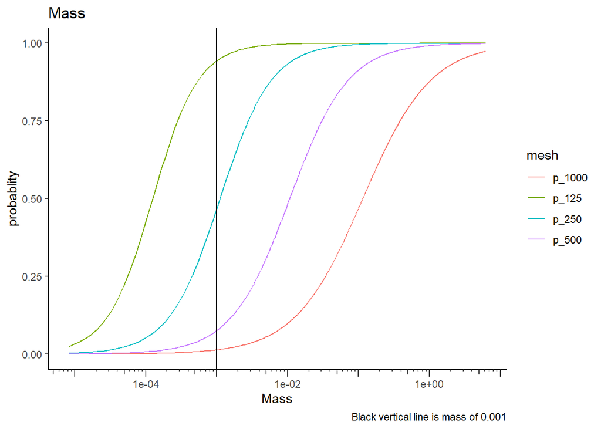

```r
p_length_mass |>
  ggplot(aes(x = xm,
             y = probablity,
             color = mesh,
             group = mesh)) +
  geom_line() +
  geom_vline(aes(xintercept = 0.001)) +
  scale_x_log10(guide = "axis_logticks") +
  theme_classic() +
  labs(x = "Mass",
       title = "Mass",
       caption = "Black vertical line is mass of 0.001")
```

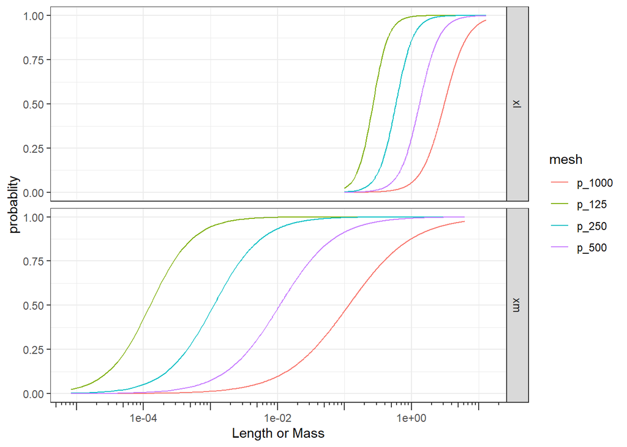

```r
p_length_mass|>
  pivot_longer(c(xm,xl)) |>
  ggplot(aes(x = value,
             y = probablity,
             color = mesh,
             group = mesh)) +
  geom_line() +
  scale_x_log10(guide = "axis_logticks") +
  theme_bw() +
  labs(x = "Length or Mass") +
  facet_grid(name~.)
```

# next round of simulations

Based on this, I propose the following:

### Body lengths with ~99% probability

```r
p_length |>
  filter(probablity>=0.989,
         probablity<=0.991) |>
  group_by(mesh) |>
  summarize(mean_l = mean(xl))
```

```
# A tibble: 3 × 2
  mesh  mean_l
  <chr>  <dbl>
1 p_125  0.901
2 p_250  2.31
3 p_500  6.32
```

`p_1000` does not show up because length = 13 only has 97.4%

### Example of mass to bias

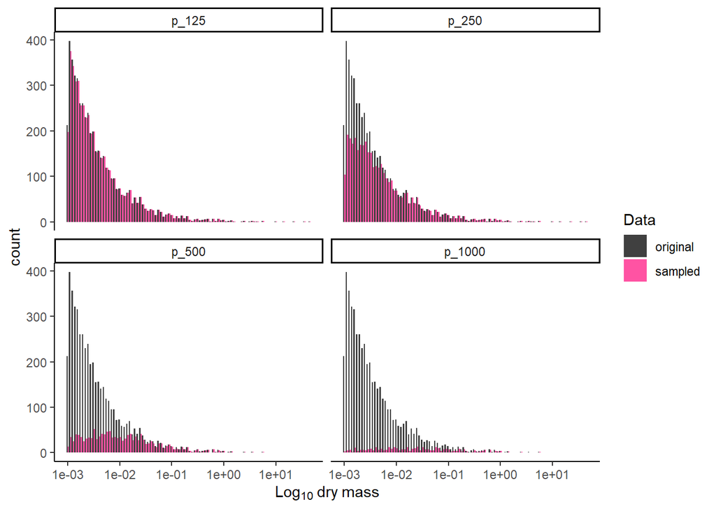

```r
# sample masses
original_m <- tibble(xm = rPLB(n = 5000,
                               b = -1.75,
                               xmin = 0.001,
                               xmax = 100),
                     fill = "original")


sampled_m <- original_m |>
  # convert masses to lengths
  mutate(xl = massToLength(xm,
                           0.005,
                           2.778),
         # use lengths to estimate sampling probability using different mesh sizes
         p_125 = plogis(morin_ln_p(L = xl,
                                   M = .125)),
         p_250 = plogis(morin_ln_p(L = xl,
                                   M = .250)),
         p_500 = plogis(morin_ln_p(L = xl,
                                   M = .50)),
         p_1000 = plogis(morin_ln_p(L = xl,
                                   M = 1))) |>
  #pivot_longer(xm:xl) |>
  pivot_longer(p_125:p_1000,
               names_to = "mesh",
               values_to = "probability") |>
  # "sample" individual body sizes based on Morin's probabilities
  mutate(
    sampled = rbinom(n(), 1, prob = probability),
    fill = case_when(sampled == 1 ~ "sampled",
                     .default = "not sampled")) |>
  select(xm, fill, mesh)

# combine the origianl, "real" data and the biased datas
both_dats <- left_join(sampled_m,
                       original_m,
                       by = "xm") |>
  pivot_longer(c(fill.x,fill.y))

# plot biased data across mesh sizes
both_dats |>
  filter(value !="not sampled") |>
  mutate(mesh = factor(mesh,
                       levels = c("p_125",
                                  "p_250",
                                  "p_500",
                                  "p_1000"))) |>
  ggplot(aes(x = xm,
             fill = value)) +
  geom_histogram(binwidth = 0.05,
                 position = "dodge",
                 alpha = 0.75) +scale_x_log10() +
  facet_wrap(~mesh) +
  scale_fill_manual(values = c("black", "#FF1984")) +
  theme_classic() +
  guides(fill = guide_legend(title= "Data")) +
  labs(x =expression(Log[10]~dry~mass))
```

If I have this right, this would basically be looking at the bias you would have in your data if you used different mesh sizes. So for most benthic macroinvertebrate sampling, the `p_250` shows the level of bias that would occur for body sizes greater than 0.001 mg dry mass. If you used a 125 um mesh, there is very little bias. However, if you used a 1 mm mesh, you basically don’t sample anything.